# Monobit Test

Ryan Durfey

Tuesday, October 14, 2014

For the creation of this random number generator, I decided to use the number of weekly web searches of the phrase “war and peace” (as a slight nod to the novel by Leo Tolstoy) from 2004 to the present (563 weeks). This data was available freely from Google Trends. In order to create a “walk” with this data, I decided to calculate the mean number of web searches over this time period and then assign a 1 to weeks that observed higher than average web searches and -1 to weeks that observed lower than average web searches. This enables us to witness a “random walk” similar to that seen in the coin flip experiments.

```r
WaP<-read.csv("WarAndPeace.csv",header=T)
NumWaP<-as.numeric(WaP[,1])
NumWaP2<-trunc(NumWaP/mean(NumWaP))
NumWaP2[NumWaP2 > "1"]<-1
NumWaP3<-(NumWaP2-0.5)*2
```

We can first plot the cumulative sum the values to get a sense of how the data “randomly walks.”

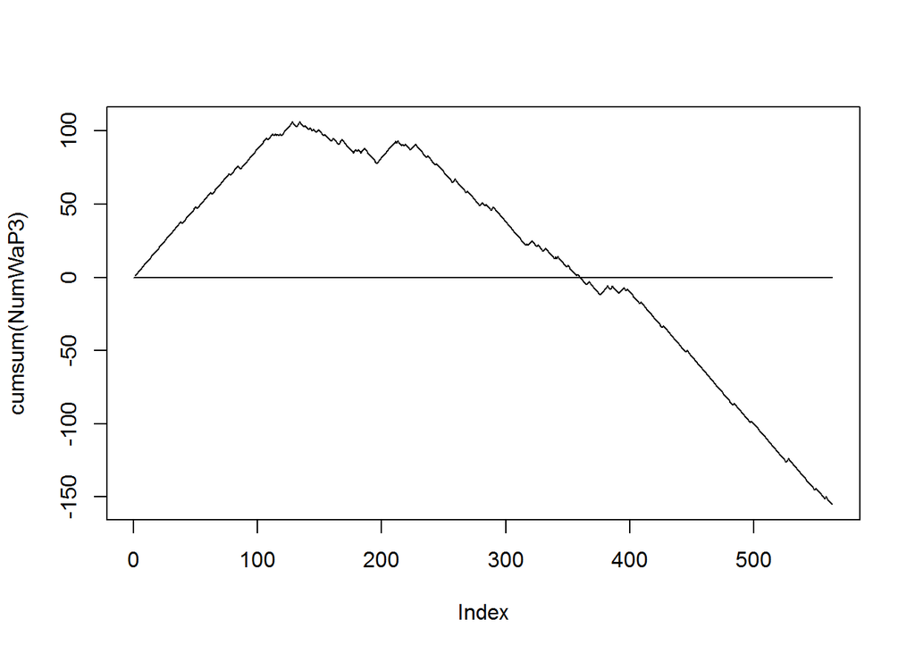

```r
plot(cumsum(NumWaP3),type="l")
lines(c(0,length(NumWaP3)),c(0,0))
```

It appears not all that different from the previous random walks we’ve observed from coin tossing experiments. The values walk up above 0, start to come down after 100, jumps back up a bit before descending toward 0 and then lower.

To use the Monobit Test to determine if this, we use the erfc function to determine the p-value, which will indicate whether or not this generator passes the test. If the p-value is less than 0.01, then it will be considered a failure.

```r
# erf<-function(x){2*pnorm(x*sqrt(2))-1}
erfc<-function(x){2*pnorm(x*sqrt(2),lower=FALSE)}
S<-erfc(abs(sum(NumWaP3)/sqrt(2*length(NumWaP3))))
S
```

```
## [1] 6.469e-11
```